# Energy Analysis

**Visualization and analysis of simulated building energy data**

- One of the biggest shopping mall of the world
- Located in United Arab Emirates (i.e. arid climate)
- Floor area is about 500,000 m2
- Number of visitors every year is around 90 million
- Building with tremendously high cooling energy demand

We will begin with visualizing some EnergyPlus simulation model data.

```python
import pandas as pd
import seaborn as sns
import matplotlib.pyplot as plt
import matplotlib
```

## Monthly Energy Visulization

Lets look at the energy consumption per month:

- The baseline data contains data from simulation model with conventional design options.

```python
base_data = pd.read_csv('./simulation_data/Baseline.csv', index_col='Month')
```

```python
base_data.head()
```

| Month | Baseline |
| --- | --- |
| January | 5.69 |
| February | 6.75 |
| March | 10.64 |
| April | 13.60 |
| May | 19.34 |

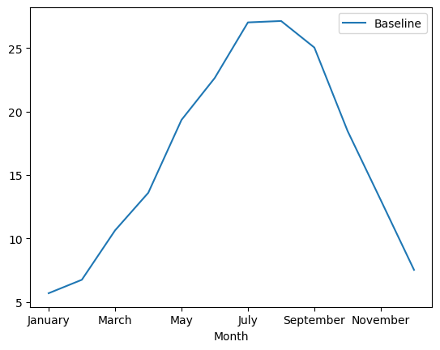

```python
base_data.plot()
```

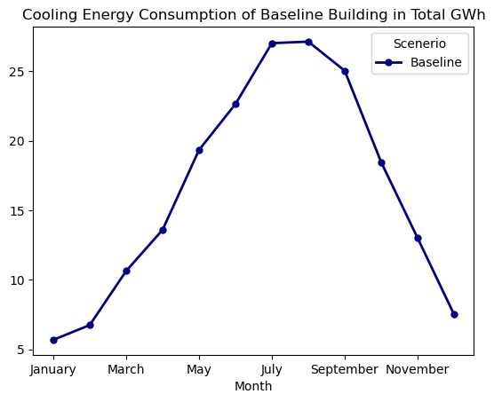

```python
base_data.columns.name='Scenerio'
base_data.plot(lw=2, colormap='jet', marker='.', markersize=10,
        title='Cooling Energy Consumption of Baseline Building in Total GWh')
```

## Different Design Options Scenerio

Baseline vs Different scheduling

- First let's take a look at one of the design options - the use of optimized schedules. Instead of the building operating 24/7, the building would have the cooling system on only during operating hours.

```python
Aircon = pd.read_csv("./simulation_data/Scenario - Aircon Schedules.csv", index_col="Month")
```

```python
Aircon
```

| Month | Scenario - Aircon Schedules |
| --- | --- |
| January | 5.61 |
| February | 6.50 |
| March | 9.70 |
| April | 11.95 |
| May | 16.52 |
| June | 18.89 |
| July | 22.13 |
| August | 22.14 |
| September | 20.38 |
| October | 15.87 |
| November | 11.71 |
| December | 7.16 |

```python
base_data
```

| Scenerio Month | Baseline |
| --- | --- |
| January | 5.69 |
| February | 6.75 |
| March | 10.64 |
| April | 13.60 |
| May | 19.34 |
| June | 22.64 |
| July | 27.02 |
| August | 27.13 |
| September | 25.04 |
| October | 18.47 |
| November | 13.02 |
| December | 7.53 |

Combine both the dataset

```python
combined_data = pd.concat([base_data, Aircon], axis=1)
```

```python
combined_data
```

| Month | Baseline | Scenario - Aircon Schedules |
| --- | --- | --- |
| January | 5.69 | 5.61 |
| February | 6.75 | 6.50 |
| March | 10.64 | 9.70 |
| April | 13.60 | 11.95 |
| May | 19.34 | 16.52 |
| June | 22.64 | 18.89 |
| July | 27.02 | 22.13 |
| August | 27.13 | 22.14 |
| September | 25.04 | 20.38 |
| October | 18.47 | 15.87 |
| November | 13.02 | 11.71 |
| December | 7.53 | 7.16 |

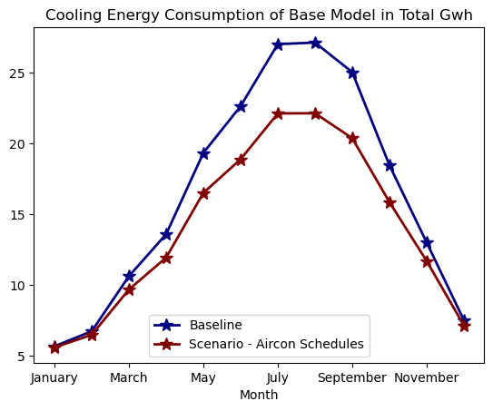

```python
combined_data.plot(lw=2, colormap='jet', marker="*", markersize=10,
                  title="Cooling Energy Consumption of Base Model in Total Gwh")
```

```python
combined_data['Difference'] = combined_data['Baseline'] - combined_data['Scenario - Aircon Schedules']
```

```python
combined_data
```

| Month | Baseline | Scenario - Aircon Schedules | Difference |
| --- | --- | --- | --- |
| January | 5.69 | 5.61 | 0.08 |
| February | 6.75 | 6.50 | 0.25 |
| March | 10.64 | 9.70 | 0.94 |
| April | 13.60 | 11.95 | 1.65 |
| May | 19.34 | 16.52 | 2.82 |
| June | 22.64 | 18.89 | 3.75 |
| July | 27.02 | 22.13 | 4.89 |
| August | 27.13 | 22.14 | 4.99 |
| September | 25.04 | 20.38 | 4.66 |
| October | 18.47 | 15.87 | 2.60 |
| November | 13.02 | 11.71 | 1.31 |
| December | 7.53 | 7.16 | 0.37 |

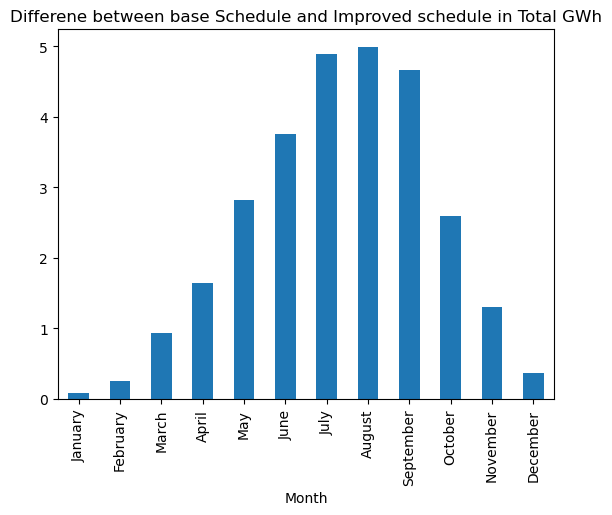

```python
combined_data['Difference'].plot.bar(title='Differene between base Schedule and Improved schedule in Total GWh')
```

## Comparing all of the options

- Glazing
- Rooftop gardens
- Thermal Comfort
- Cool paiting on the roof

```python
list_of_files = ['Scenario - Aircon Schedules.csv',
 'Scenario - Cool roof.csv',
 'Scenario - Rooftop Gardens.csv',
 'Scenario - Increase Setpoint.csv',
 'Scenario - Low-E Glass.csv',
 'Baseline.csv']
```

```python
data_container = []
for file_name in list_of_files:
    df = pd.read_csv("./simulation_data/" + file_name, index_col='Month')
    data_container.append(df)

merged = pd.concat(data_container, axis=1)
```

```python
merged
```

| Month | Scenario - Aircon Schedules | Scenario - Cool roof | Scenario - Rooftop Gardens | Scenario - Increase Setpoint | Scenario - Low-E Glass | Baseline |
| --- | --- | --- | --- | --- | --- | --- |
| January | 5.61 | 4.46 | 6.30 | 2.73 | 5.41 | 5.69 |
| February | 6.50 | 5.39 | 7.15 | 3.88 | 6.48 | 6.75 |
| March | 9.70 | 8.96 | 10.90 | 6.60 | 10.37 | 10.64 |
| April | 11.95 | 11.73 | 13.59 | 9.37 | 13.36 | 13.60 |
| May | 16.52 | 17.28 | 18.94 | 14.82 | 19.14 | 19.34 |
| June | 18.89 | 20.54 | 22.12 | 18.01 | 22.47 | 22.64 |
| July | 22.13 | 24.76 | 26.29 | 21.98 | 26.84 | 27.02 |
| August | 22.14 | 24.97 | 26.47 | 22.15 | 26.91 | 27.13 |
| September | 20.38 | 22.98 | 24.63 | 19.92 | 24.77 | 25.04 |
| October | 15.87 | 16.57 | 18.51 | 13.65 | 18.16 | 18.47 |
| November | 11.71 | 11.41 | 13.55 | 8.49 | 12.69 | 13.02 |
| December | 7.16 | 6.36 | 8.19 | 4.15 | 7.24 | 7.53 |

```python
merged.info()
```

```
<class 'pandas.core.frame.DataFrame'>
Index: 12 entries, January to December
Data columns (total 6 columns):
 #   Column                        Non-Null Count  Dtype
---  ------                        --------------  -----
 0   Scenario - Aircon Schedules   12 non-null     float64
 1   Scenario - Cool roof          12 non-null     float64
 2   Scenario - Rooftop Gardens    12 non-null     float64
 3   Scenario - Increase Setpoint  12 non-null     float64
 4   Scenario - Low-E Glass        12 non-null     float64
 5   Baseline                      12 non-null     float64
dtypes: float64(6)
memory usage: 672.0+ bytes
```

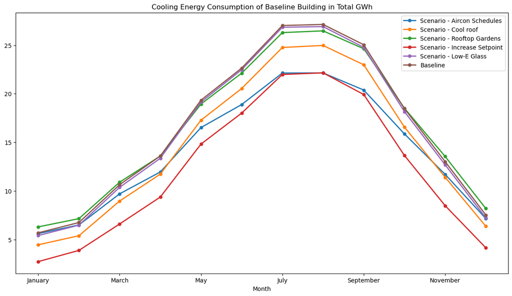

```python
merged.plot(lw=2, marker='.', markersize=10,
        title='Cooling Energy Consumption of Baseline Building in Total GWh', figsize=(15,8))
```

Lets see the total energy consumption reduction from each design options

```python
merged
```

| Month | Scenario - Aircon Schedules | Scenario - Cool roof | Scenario - Rooftop Gardens | Scenario - Increase Setpoint | Scenario - Low-E Glass | Baseline |
| --- | --- | --- | --- | --- | --- | --- |
| January | 5.61 | 4.46 | 6.30 | 2.73 | 5.41 | 5.69 |
| February | 6.50 | 5.39 | 7.15 | 3.88 | 6.48 | 6.75 |
| March | 9.70 | 8.96 | 10.90 | 6.60 | 10.37 | 10.64 |
| April | 11.95 | 11.73 | 13.59 | 9.37 | 13.36 | 13.60 |
| May | 16.52 | 17.28 | 18.94 | 14.82 | 19.14 | 19.34 |
| June | 18.89 | 20.54 | 22.12 | 18.01 | 22.47 | 22.64 |
| July | 22.13 | 24.76 | 26.29 | 21.98 | 26.84 | 27.02 |
| August | 22.14 | 24.97 | 26.47 | 22.15 | 26.91 | 27.13 |
| September | 20.38 | 22.98 | 24.63 | 19.92 | 24.77 | 25.04 |
| October | 15.87 | 16.57 | 18.51 | 13.65 | 18.16 | 18.47 |
| November | 11.71 | 11.41 | 13.55 | 8.49 | 12.69 | 13.02 |
| December | 7.16 | 6.36 | 8.19 | 4.15 | 7.24 | 7.53 |

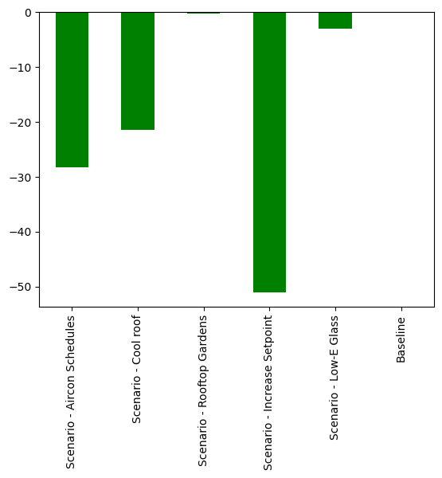

```python
merged.subtract(merged['Baseline'], axis=0).sum().plot.bar(color='green')
```

# Time Series Data Analysis - Meter Data Analysis

For this section, we will be using the Building Data Genome Project:

https://github.com/buds-lab/the-building-data-genome-project

[figure not shown]

- This project is a set of 500+ time-series meter data from buildings -- check out the website which includes an overview of the data set, sources, and publications that use the data set.
- we will use some of the buildings from that data set to understand why Pandas was designed for time-series data from IoT networks

Let's load the data from a single building for the meter_data folder- building name is Amelia

```python
amelia = pd.read_csv('./meter_data/Office_Amelia.csv', index_col='timestamp')
```

```python
amelia.head()
```

| timestamp | Office_Amelia |
| --- | --- |
| 2015-01-01 00:00:00 | 3.96 |
| 2015-01-01 01:00:00 | 4.44 |
| 2015-01-01 02:00:00 | 4.82 |
| 2015-01-01 03:00:00 | 4.28 |
| 2015-01-01 04:00:00 | 18.79 |

```python
amelia.info()
```

```
<class 'pandas.core.frame.DataFrame'>
Index: 8760 entries, 2015-01-01 00:00:00 to 2015-12-31 23:00:00
Data columns (total 1 columns):
 #   Column         Non-Null Count  Dtype
---  ------         --------------  -----
 0   Office_Amelia  8760 non-null   float64
dtypes: float64(1)
memory usage: 136.9+ KB
```

```python
amelia.index[0]
```

```
'2015-01-01 00:00:00'
```

### Convert timestamp index to a datetime object

```python
amelia = pd.read_csv('./meter_data/Office_Amelia.csv', index_col='timestamp', parse_dates=True)
```

```python
amelia.head()
```

| timestamp | Office_Amelia |
| --- | --- |
| 2015-01-01 00:00:00 | 3.96 |
| 2015-01-01 01:00:00 | 4.44 |
| 2015-01-01 02:00:00 | 4.82 |
| 2015-01-01 03:00:00 | 4.28 |
| 2015-01-01 04:00:00 | 18.79 |

```python
amelia.index[0]
```

```
Timestamp('2015-01-01 00:00:00')
```

Timestamp is the pandas equivalent of python's Datetime

### Plot Simple Charts of time-series data

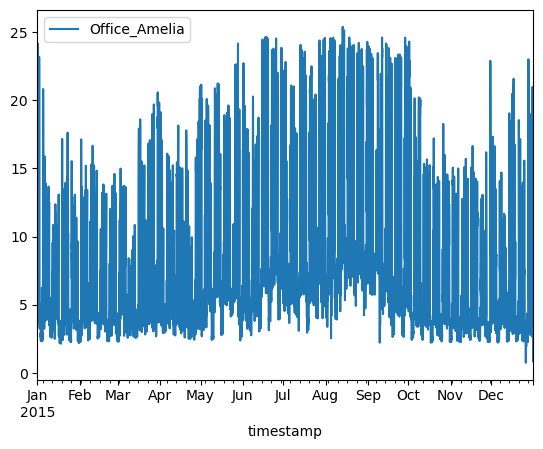

```python
amelia.plot()
```

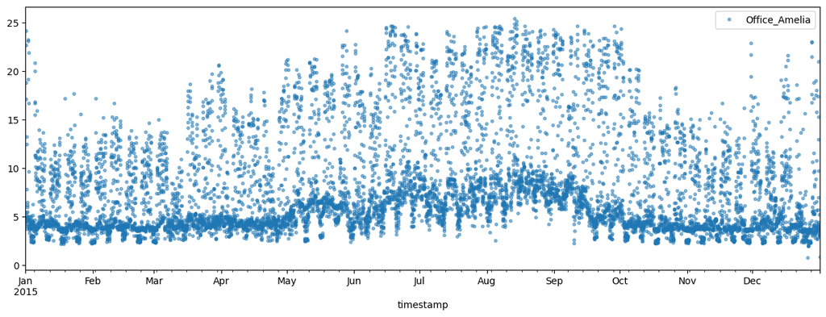

```python
amelia.plot(marker=".", linestyle='None', alpha=0.5, figsize=(15, 5))
```

### Resample the data

Two types of resampling are:

- Upsampling: Where you increase the frequency of the samples, such as from minutes to seconds.
- Downsampling: Where you decrease the frequency of the samples, such as from days to months.
- We will focus here on downsampling, exploring how it can help us analyze our OPSD data on various time scales

```python
amelia.head()
```

| timestamp | Office_Amelia |
| --- | --- |
| 2015-01-01 00:00:00 | 3.96 |
| 2015-01-01 01:00:00 | 4.44 |
| 2015-01-01 02:00:00 | 4.82 |
| 2015-01-01 03:00:00 | 4.28 |
| 2015-01-01 04:00:00 | 18.79 |

```python
amelia_daily = amelia.resample("D").mean(numeric_only=True)
```

```python
amelia_daily.head()
```

| timestamp | Office_Amelia |
| --- | --- |
| 2015-01-01 | 8.323750 |
| 2015-01-02 | 7.865417 |
| 2015-01-03 | 3.695417 |
| 2015-01-04 | 3.680417 |
| 2015-01-05 | 8.948333 |

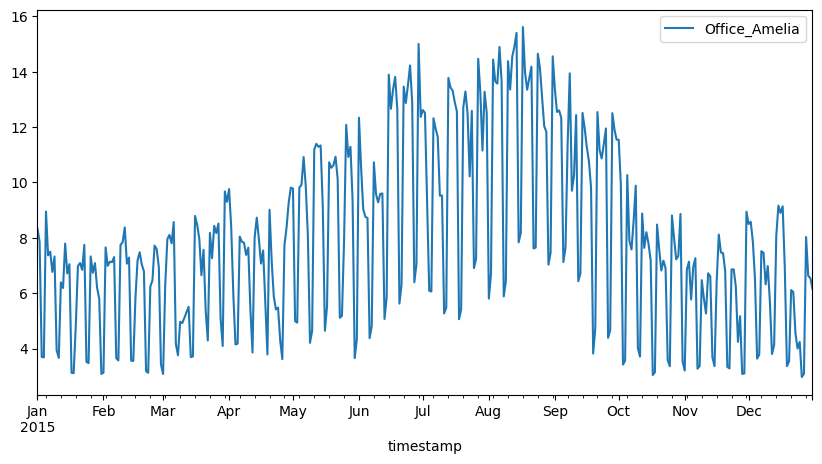

```python
amelia_daily.plot(figsize=(10, 5))
```

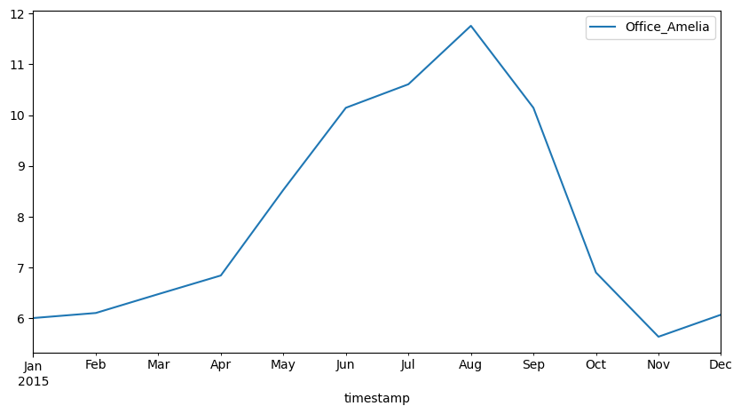

```python
amelia_daily.resample('M').mean().plot(figsize=(10, 5))
```

### Analysis of a large number of buildings at once

we will select few for the building from the dataset

```python
list_of_buildings = [
    'UnivClass_Andy.csv',
    'Office_Alannah.csv',
    'PrimClass_Angel.csv',
    'Office_Penny.csv',
    'UnivLab_Allison.csv',
    'Office_Amelia.csv',
    'UnivClass_Alfredo.csv',
    'Office_Phebian.csv',
    'UnivLab_Adrian.csv',
    'UnivDorm_Curtis.csv',
    'UnivLab_Angie.csv',
    'UnivClass_Amya.csv',
    'UnivLab_Audra.csv',
]
```

```python
data_container_list = []
for building_name in list_of_buildings:
    df = pd.read_csv("./meter_data/" + building_name, index_col='timestamp', parse_dates=True)
    df = df.resample("D").mean()
    data_container_list.append(df)
all_merged = pd.concat(data_container_list, axis=1)
```

```
array([<Axes: xlabel='timestamp'>, <Axes: xlabel='timestamp'>,
       <Axes: xlabel='timestamp'>, <Axes: xlabel='timestamp'>,
       <Axes: xlabel='timestamp'>, <Axes: xlabel='timestamp'>,
       <Axes: xlabel='timestamp'>, <Axes: xlabel='timestamp'>,
       <Axes: xlabel='timestamp'>, <Axes: xlabel='timestamp'>,
       <Axes: xlabel='timestamp'>, <Axes: xlabel='timestamp'>,
       <Axes: xlabel='timestamp'>], dtype=object)
```

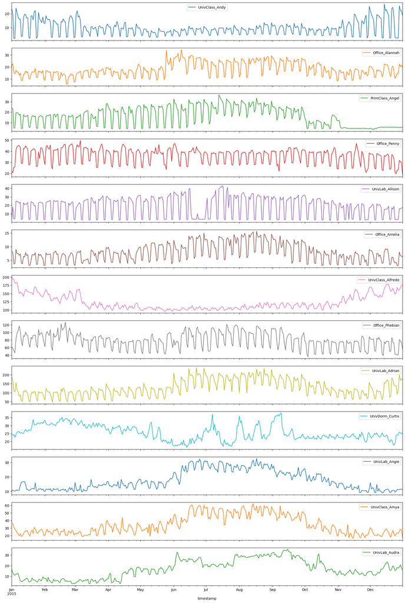

```python
all_merged.plot(figsize=(20, 30), subplots=True)
```

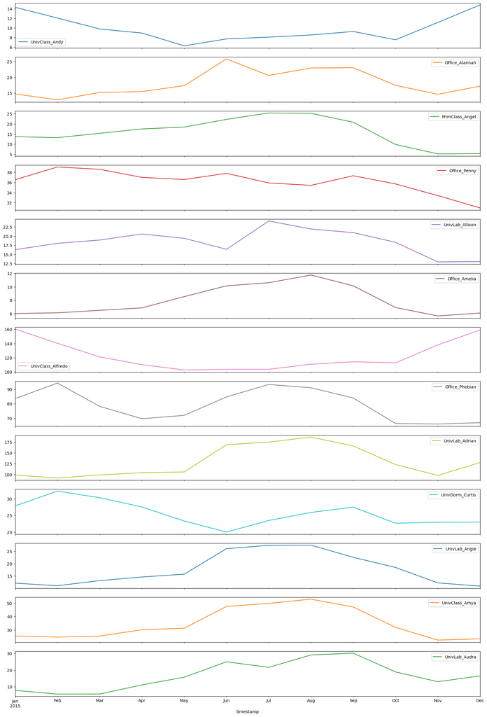

```python
all_merged.resample("M").mean().plot(figsize=(20,30), subplots=True);
```

# Compare consumption of buildings to be each other

- Buildings come in all shapes, sizes and uses. It is difficult to compare the energy consumption of two buildings if they are not similar in these ways
- So we will Normalize energy consumption data of buildings to be able to compare them to each other¶

```python
# Here we will take different building
building_name = "Office_Penny"
raw_data = pd.read_csv("./meter_data/"+building_name+".csv", parse_dates=True, index_col='timestamp')
```

```python
raw_data.info()
```

```
<class 'pandas.core.frame.DataFrame'>
DatetimeIndex: 8760 entries, 2015-01-01 00:00:00 to 2015-12-31 23:00:00
Data columns (total 1 columns):
 #   Column        Non-Null Count  Dtype
---  ------        --------------  -----
 0   Office_Penny  8760 non-null   float64
dtypes: float64(1)
memory usage: 136.9 KB
```

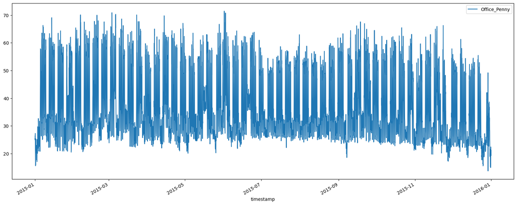

```python
raw_data.plot(figsize=(20, 8))
```

### Normalize by floor area

- EUI - Energy Use Intensity - This metric takes energy and simply divides by the floor area (in ft2 or m2)

```python
metadata = pd.read_csv('./all_buildings_meta_data.csv', index_col="uid")
```

```python
metadata.head()
```

| uid | dataend | datastart | energystarscore | heatingtype | industry | mainheatingtype | numberoffloors | occupants | primaryspaceusage | rating | sqft | sqm | subindustry | timezone | yearbuilt | nickname | primaryspaceuse_abbrev | newweatherfilename |
| --- | --- | --- | --- | --- | --- | --- | --- | --- | --- | --- | --- | --- | --- | --- | --- | --- | --- | --- |
| PrimClass_Everett | 31/12/12 23:00 | 01/01/12 00:00 | NaN | NaN | Education | NaN | NaN | NaN | Primary/Secondary Classroom | NaN | 105530.0 | 9804.053590 | Primary/Secondary School | America/New_York | NaN | Everett | PrimClass | weather12.csv |
| UnivClass_Clifford | 31/12/15 23:00 | 01/01/15 00:00 | NaN | NaN | Education | NaN | NaN | NaN | College Classroom | NaN | 56969.0 | 5292.591007 | College/University | America/New_York | 1967 | Clifford | UnivClass | weather2.csv |
| Office_Elizabeth | 31/12/12 23:00 | 01/01/12 00:00 | NaN | NaN | Commercial Property | NaN | NaN | NaN | Office | NaN | 294651.0 | 27373.961850 | Commercial Real Estate | America/Los_Angeles | NaN | Elizabeth | Office | weather22.csv |
| Office_Ellie | 31/12/12 23:00 | 01/01/12 00:00 | NaN | NaN | Commercial Property | NaN | NaN | NaN | Office | NaN | 496517.0 | 46127.918850 | Bank/Financial Services | America/Los_Angeles | NaN | Ellie | Office | weather28.csv |
| PrimClass_Elisabeth | 31/12/12 23:00 | 01/01/12 00:00 | NaN | NaN | Education | NaN | NaN | NaN | Primary/Secondary Classroom | NaN | 233062.0 | 21652.158990 | Primary/Secondary School | America/New_York | NaN | Elisabeth | PrimClass | weather23.csv |

```python
metadata.loc[building_name]
```

```
dataend                       31/12/15 23:00
datastart                     01/01/15 00:00
energystarscore                          NaN
heatingtype                              NaN
industry                           Education
mainheatingtype                          NaN
numberoffloors                           NaN
occupants                                NaN
primaryspaceusage                     Office
rating                                   NaN
sqft                                 37485.0
sqm                              3482.468955
subindustry               College/University
timezone                    America/New_York
yearbuilt                                NaN
nickname                               Penny
primaryspaceuse_abbrev                Office
newweatherfilename              weather4.csv
Name: Office_Penny, dtype: object
```

```python
sqm = metadata.loc[building_name]["sqm"]
sqm
```

```
3482.468955
```

```python
raw_data.head()
```

| timestamp | Office_Penny |
| --- | --- |
| 2015-01-01 00:00:00 | 25.275000 |
| 2015-01-01 01:00:00 | 25.625000 |
| 2015-01-01 02:00:00 | 25.158333 |
| 2015-01-01 03:00:00 | 24.900000 |
| 2015-01-01 04:00:00 | 26.358333 |

```python
normazlied_rawdata = raw_data / sqm
```

```python
normazlied_rawdata.head()
```

| timestamp | Office_Penny |
| --- | --- |
| 2015-01-01 00:00:00 | 0.007258 |
| 2015-01-01 01:00:00 | 0.007358 |
| 2015-01-01 02:00:00 | 0.007224 |
| 2015-01-01 03:00:00 | 0.007150 |
| 2015-01-01 04:00:00 | 0.007569 |

```python
monthly_normalized = normazlied_rawdata.resample('M').sum()
```

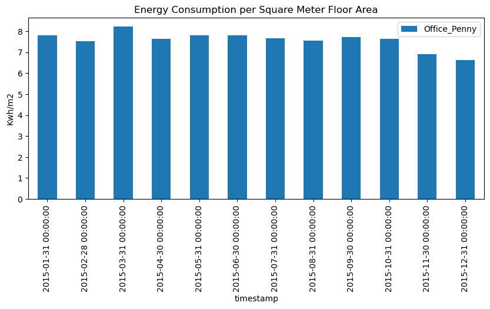

```python
monthly_normalized.plot(kind="bar", figsize=(10,4), title='Energy Consumption per Square Meter Floor Area')
plt.ylabel("Kwh/m2")
```

### Analysis on multiple buildings¶

```python
buildingnamelist = [
    "Office_Abbey",
    "Office_Pam",
    "Office_Penny",
    "UnivLab_Allison",
    "UnivLab_Audra",
    "UnivLab_Ciel"]
```

```python
annual_data_list = []
annual_data_list_normalized = []
```

```python
for buildingname in buildingnamelist:
    print("Getting data from: "+buildingname)

    rawdata = pd.read_csv("./meter_data/"+buildingname+".csv", parse_dates=True, index_col='timestamp')
    floor_area = metadata.loc[buildingname]["sqm"]

    annual = rawdata.sum()

    normalized_data = rawdata/floor_area
    annual_normalized = normalized_data.sum()

    annual_data_list_normalized.append(annual_normalized)
    annual_data_list.append(annual)
```

```
Getting data from: Office_Abbey
Getting data from: Office_Pam
Getting data from: Office_Penny
Getting data from: UnivLab_Allison
Getting data from: UnivLab_Audra
Getting data from: UnivLab_Ciel
```

```python
totaldata = pd.concat(annual_data_list)
totaldata_normalized = pd.concat(annual_data_list_normalized)
```

```python
totaldata
```

```
Office_Abbey       4.500047e+05
Office_Pam         9.239849e+05
Office_Penny       3.167204e+05
UnivLab_Allison    1.614309e+05
UnivLab_Audra      1.466867e+05
UnivLab_Ciel       3.122984e+06
dtype: float64
```

```python
totaldata_normalized
```

```
Office_Abbey        65.298087
Office_Pam          95.022257
Office_Penny        90.947091
UnivLab_Allison    370.575397
UnivLab_Audra      344.517297
UnivLab_Ciel       143.740305
dtype: float64
```

#### Unnormalized energy consumption

see from the annual totals of energy consumption, the Lab named Ciel uses a lot of energy as compared to the other buildings!

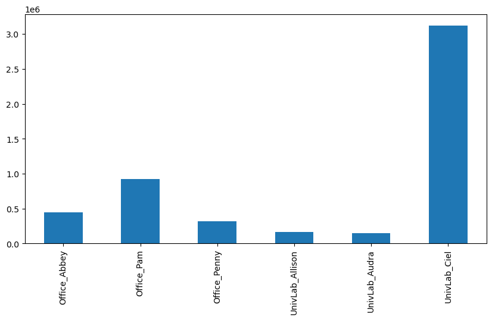

```python
totaldata.plot(kind='bar',figsize=(10,5))
```

#### Normalized Energy Consumption

But, when normalized using floor area, Ciel is not the highest consumer

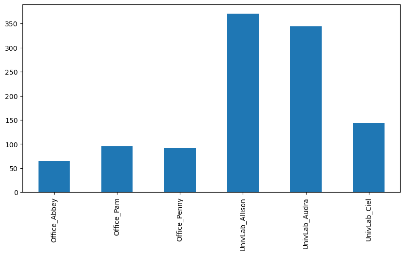

```python
totaldata_normalized.plot(kind='bar',figsize=(10,5))
```

# Weather Influence on Energy Consumption

```python
%matplotlib inline
```

```python
ciara_rawdata = pd.read_csv("./meter_data/UnivClass_Ciara.csv", parse_dates=True, index_col='timestamp')
```

```python
ciara_rawdata.info()
```

```
<class 'pandas.core.frame.DataFrame'>
DatetimeIndex: 8760 entries, 2015-01-01 00:00:00 to 2015-12-31 23:00:00
Data columns (total 1 columns):
 #   Column           Non-Null Count  Dtype
---  ------           --------------  -----
 0   UnivClass_Ciara  8760 non-null   float64
dtypes: float64(1)
memory usage: 136.9 KB
```

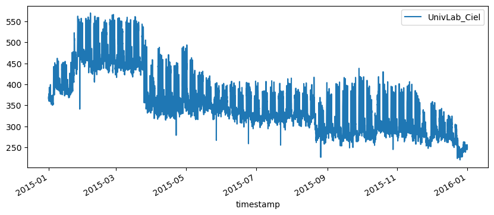

```python
rawdata.plot(figsize=(10,4))
```

```python
metadata.loc['UnivClass_Ciara']
```

```
dataend                       31/12/15 23:00
datastart                     01/01/15 00:00
energystarscore                          NaN
heatingtype                              NaN
industry                           Education
mainheatingtype                          NaN
numberoffloors                           NaN
occupants                                NaN
primaryspaceusage          College Classroom
rating                                   NaN
sqft                                140488.0
sqm                              13051.75666
subindustry               College/University
timezone                    America/New_York
yearbuilt                               1961
nickname                               Ciara
primaryspaceuse_abbrev             UnivClass
newweatherfilename              weather2.csv
Name: UnivClass_Ciara, dtype: object
```

For the university class building "UnivClass_Ciara" the weather data is weather2.csv as we can see from the meta data.

```python
weather_data_ciara = pd.read_csv("./weather_data/weather2.csv", index_col='timestamp', parse_dates=True)
```

```python
weather_data_ciara.head()
```

| timestamp | Conditions | DateUTC<br /> | Dew PointC | Events | Gust SpeedKm/h | Humidity | Precipitationmm | Sea Level PressurehPa | TemperatureC | TimeEDT | TimeEST | VisibilityKm | Wind Direction | Wind SpeedKm/h | WindDirDegrees | timestamp.1 |
| --- | --- | --- | --- | --- | --- | --- | --- | --- | --- | --- | --- | --- | --- | --- | --- | --- |
| 2015-01-01 00:56:00 | Overcast | 2015-01-01 05:56:00<br /> | -15.0 | NaN | - | 54.0 | NaN | 1017.4 | -7.2 | NaN | 12:56 AM | 16.1 | SW | 18.5 | 230 | 2015-01-01 00:56:00 |
| 2015-01-01 01:56:00 | Overcast | 2015-01-01 06:56:00<br /> | -14.4 | NaN | - | 55.0 | NaN | 1017.2 | -6.6 | NaN | 1:56 AM | 16.1 | WSW | 14.8 | 240 | 2015-01-01 01:56:00 |
| 2015-01-01 02:56:00 | Overcast | 2015-01-01 07:56:00<br /> | -14.4 | NaN | - | 55.0 | NaN | 1016.9 | -6.6 | NaN | 2:56 AM | 16.1 | SW | 14.8 | 220 | 2015-01-01 02:56:00 |
| 2015-01-01 03:56:00 | Overcast | 2015-01-01 08:56:00<br /> | -14.4 | NaN | - | 55.0 | NaN | 1017.2 | -6.6 | NaN | 3:56 AM | 16.1 | SW | 18.5 | 220 | 2015-01-01 03:56:00 |
| 2015-01-01 04:56:00 | Overcast | 2015-01-01 09:56:00<br /> | -14.4 | NaN | - | 55.0 | NaN | 1017.2 | -6.6 | NaN | 4:56 AM | 16.1 | SSW | 14.8 | 210 | 2015-01-01 04:56:00 |

```python
weather_data_ciara.info()
```

```
<class 'pandas.core.frame.DataFrame'>
DatetimeIndex: 10914 entries, 2015-01-01 00:56:00 to 2015-12-31 21:56:00
Data columns (total 16 columns):
 #   Column                 Non-Null Count  Dtype
---  ------                 --------------  -----
 0   Conditions             10914 non-null  object
 1   DateUTC<br />          10914 non-null  object
 2   Dew PointC             10914 non-null  float64
 3   Events                 2555 non-null   object
 4   Gust SpeedKm/h         10914 non-null  object
 5   Humidity               10878 non-null  float64
 6   Precipitationmm        2945 non-null   float64
 7   Sea Level PressurehPa  10914 non-null  float64
 8   TemperatureC           10914 non-null  float64
 9   TimeEDT                7104 non-null   object
 10  TimeEST                3810 non-null   object
 11  VisibilityKm           10914 non-null  float64
 12  Wind Direction         10914 non-null  object
 13  Wind SpeedKm/h         10914 non-null  object
 14  WindDirDegrees         10914 non-null  int64
 15  timestamp.1            10914 non-null  object
dtypes: float64(6), int64(1), object(9)
memory usage: 1.4+ MB
```

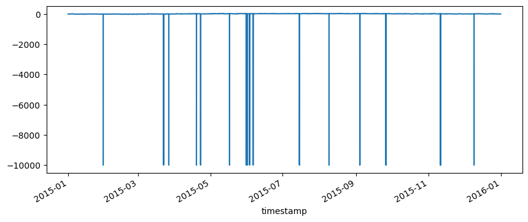

```python
weather_data_ciara['TemperatureC'].plot(figsize=(10, 4))
```

```python
weather_hourly = weather_data_ciara.resample('H').mean(numeric_only=True)
```

```python
weather_hourly_nooutlier = weather_hourly[weather_hourly > -40]
```

```python
weather_hourly['TemperatureC'].info()
```

```
<class 'pandas.core.series.Series'>
DatetimeIndex: 8758 entries, 2015-01-01 00:00:00 to 2015-12-31 21:00:00
Freq: H
Series name: TemperatureC
Non-Null Count  Dtype
--------------  -----
8567 non-null   float64
dtypes: float64(1)
memory usage: 136.8 KB
```

```python
weather_hourly_nooutlier['TemperatureC'].info()
```

```
<class 'pandas.core.series.Series'>
DatetimeIndex: 8758 entries, 2015-01-01 00:00:00 to 2015-12-31 21:00:00
Freq: H
Series name: TemperatureC
Non-Null Count  Dtype
--------------  -----
8544 non-null   float64
dtypes: float64(1)
memory usage: 136.8 KB
```

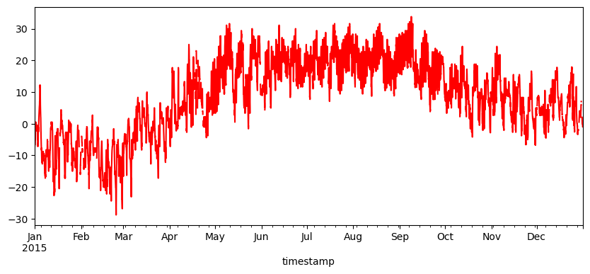

```python
weather_hourly_nooutlier['TemperatureC'].plot(figsize=(10, 4), color='red')
```

### Filling gaps in data

We can fill the gap left by filtering the outliers by using the `.fillna()` function

```python
weather_nooutlier_nogaps = weather_hourly_nooutlier.fillna(method='ffill')
```

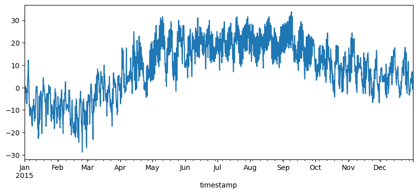

```python
weather_nooutlier_nogaps["TemperatureC"].plot(figsize=(10,4))
```

### Combine Temperature and Electricity data

```python
weather_nooutlier_nogaps['TemperatureC'].head()
```

```
timestamp
2015-01-01 00:00:00   -7.2
2015-01-01 01:00:00   -6.6
2015-01-01 02:00:00   -6.6
2015-01-01 03:00:00   -6.6
2015-01-01 04:00:00   -6.6
Freq: H, Name: TemperatureC, dtype: float64
```

```python
rawdata = ciara_rawdata[~ciara_rawdata.index.duplicated(keep='first')]
```

Using `.concat()` and `.merger()` function to combine dataset

```python
combined = pd.concat([weather_nooutlier_nogaps['TemperatureC'], rawdata['UnivClass_Ciara']], axis=1)
```

```python
merged = pd.merge(weather_nooutlier_nogaps['TemperatureC'], rawdata['UnivClass_Ciara'], left_index=True, right_index=True, how='outer')
```

```python
merged.head()
```

| timestamp | TemperatureC | UnivClass_Ciara |
| --- | --- | --- |
| 2015-01-01 00:00:00 | -7.2 | 136.824997 |
| 2015-01-01 01:00:00 | -6.6 | 144.025002 |
| 2015-01-01 02:00:00 | -6.6 | 144.875000 |
| 2015-01-01 03:00:00 | -6.6 | 142.375000 |
| 2015-01-01 04:00:00 | -6.6 | 148.199997 |

```
array([<Axes: xlabel='timestamp'>, <Axes: xlabel='timestamp'>],
      dtype=object)
```

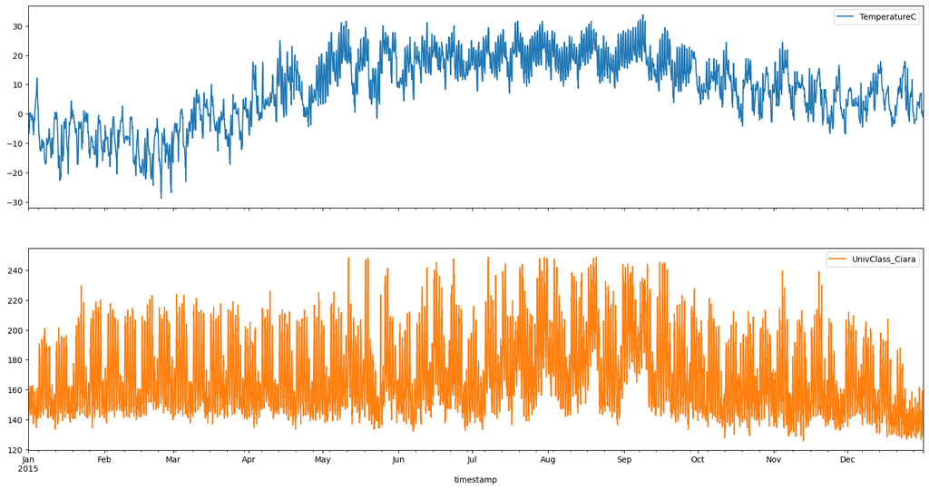

```python
merged.plot(figsize=(20, 10), subplots=True)
```

### Analyze the weather influence on energy consumption

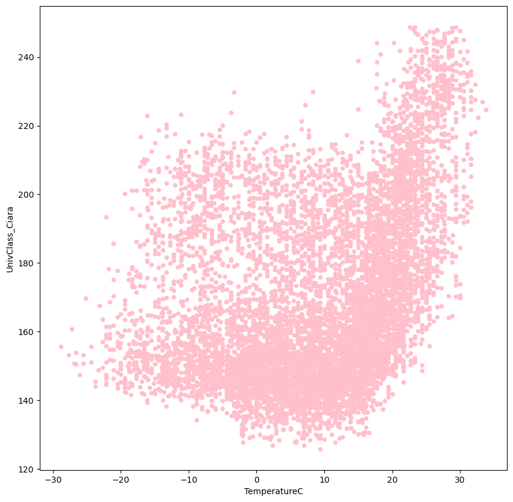

```python
merged.plot(kind='scatter', x='TemperatureC', y='UnivClass_Ciara', figsize=(10,10), color='pink')
```

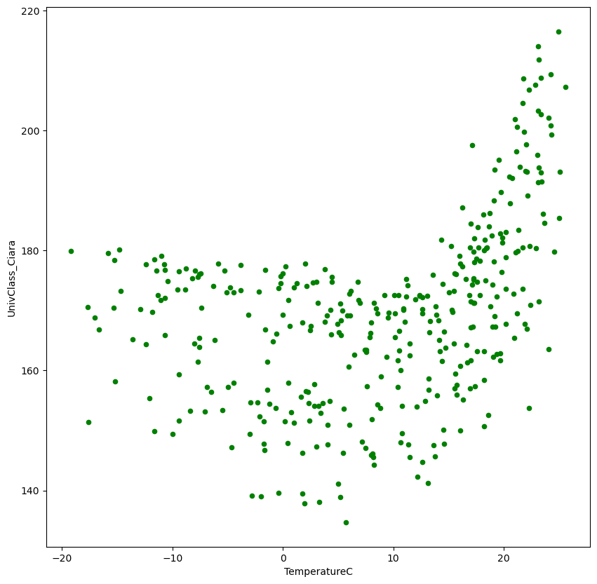

```python
merged.resample("D").mean().plot(kind='scatter', x='TemperatureC', y='UnivClass_Ciara', figsize=(10,10), color='green')
```

### Visualizations using Seaborn

```python
def make_color_division(x):
    if x < 10:
        return "Heating"
    else:
        return "Cooling"
```

```python
combined = merged.resample("D").mean()
```

```python
combined.head()
```

| timestamp | TemperatureC | UnivClass_Ciara |
| --- | --- | --- |
| 2015-01-01 | -3.027083 | 149.362500 |
| 2015-01-02 | -1.704167 | 151.513542 |
| 2015-01-03 | -1.707639 | 147.725000 |
| 2015-01-04 | 7.135417 | 148.089584 |
| 2015-01-05 | -7.598958 | 163.968750 |

```python
combined['heating_vs_cooling'] = combined.TemperatureC.apply(lambda x: make_color_division(x))
```

```python
combined.head()
```

| timestamp | TemperatureC | UnivClass_Ciara | heating_vs_cooling |
| --- | --- | --- | --- |
| 2015-01-01 | -3.027083 | 149.362500 | Heating |
| 2015-01-02 | -1.704167 | 151.513542 | Heating |
| 2015-01-03 | -1.707639 | 147.725000 | Heating |
| 2015-01-04 | 7.135417 | 148.089584 | Heating |
| 2015-01-05 | -7.598958 | 163.968750 | Heating |

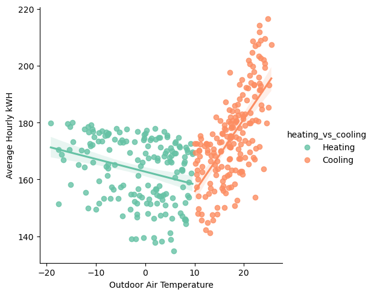

```python
g = sns.lmplot(x="TemperatureC", y="UnivClass_Ciara", hue="heating_vs_cooling",
               truncate=True, data=combined, palette='Set2')

g.set_axis_labels("Outdoor Air Temperature", "Average Hourly kWH")
```

# Indoor Environment Quality Analysis

- For this section we will use the ASHRAE Thermal Comfort Database II.

The publication that outlines how the database was created is here: https://www.researchgate.net/publication/325848721_Development_of_the_ASHRAE_Global_Thermal_Comfort_Database_II

```python
ashrae_data = pd.read_csv("./ashrae_thermal_comfort_database_2.csv", index_col='Unnamed: 0')
```

```python
ashrae_data.head()
```

|  | Publication (Citation) | Year | Season | Climate | City | Country | Building type | Cooling startegy_building level | Sex | Thermal sensation | Clo | Met | Air temperature (C) | Relative humidity (%) | Air velocity (m/s) | ThermalSensation_rounded |
| --- | --- | --- | --- | --- | --- | --- | --- | --- | --- | --- | --- | --- | --- | --- | --- | --- |
| 2233 | Indraganti, Madhavi, et al. "Adaptive model of... | 2012.0 | Winter | Tropical wet savanna | Chennai | India | Office | Mixed Mode | Female | -2.0 | 0.75 | 1.0 | 25.2 | 64.0 | 0.1 | -2.0 |
| 2234 | Indraganti, Madhavi, et al. "Adaptive model of... | 2012.0 | Winter | Tropical wet savanna | Chennai | India | Office | Mixed Mode | Male | -1.0 | 0.64 | 1.0 | 25.2 | 64.0 | 0.1 | -1.0 |
| 2235 | Indraganti, Madhavi, et al. "Adaptive model of... | 2012.0 | Winter | Tropical wet savanna | Chennai | India | Office | Mixed Mode | Male | -2.0 | 0.64 | 1.0 | 25.2 | 64.0 | 0.1 | -2.0 |
| 2236 | Indraganti, Madhavi, et al. "Adaptive model of... | 2012.0 | Winter | Tropical wet savanna | Chennai | India | Office | Mixed Mode | Female | -2.0 | 0.75 | 1.0 | 25.2 | 64.0 | 0.1 | -2.0 |
| 2237 | Indraganti, Madhavi, et al. "Adaptive model of... | 2012.0 | Winter | Tropical wet savanna | Chennai | India | Office | Mixed Mode | Male | 0.0 | 0.72 | 1.0 | 25.2 | 64.0 | 0.1 | 0.0 |

### Summarizing Data

```python
ashrae_data.describe()
```

|  | Year | Thermal sensation | Clo | Met | Air temperature (C) | Relative humidity (%) | Air velocity (m/s) | ThermalSensation_rounded |
| --- | --- | --- | --- | --- | --- | --- | --- | --- |
| count | 43448.000000 | 43448.000000 | 43448.000000 | 43448.000000 | 43448.000000 | 43448.000000 | 43448.000000 | 43448.000000 |
| mean | 2003.163621 | 0.127440 | 0.634063 | 1.177975 | 25.215932 | 51.553517 | 0.202853 | 0.128222 |
| std | 10.326515 | 1.125046 | 0.255987 | 0.251705 | 3.426420 | 14.709984 | 0.317471 | 1.127096 |
| min | 1982.000000 | -3.000000 | 0.000000 | 0.700000 | 13.100000 | 0.500000 | 0.000000 | -3.000000 |
| 25% | 1994.000000 | -0.500000 | 0.470000 | 1.000000 | 22.900000 | 41.400000 | 0.060000 | 0.000000 |
| 50% | 2010.000000 | 0.000000 | 0.620000 | 1.100000 | 24.700000 | 51.600000 | 0.100000 | 0.000000 |
| 75% | 2012.000000 | 1.000000 | 0.720000 | 1.200000 | 27.200000 | 62.400000 | 0.210000 | 1.000000 |
| max | 2016.000000 | 3.000000 | 2.870000 | 6.830000 | 48.800000 | 97.800000 | 6.540000 | 3.000000 |

```python
ashrae_data['Clo'].sum()
```

```
27548.78
```

```python
ashrae_data['Clo'].mean()
```

```
0.6340632480206223
```

```python
ashrae_data['Clo'].std()
```

```
0.25598709252418184
```

### Understanding the diversity of data

This data contains lot of categories in column

```python
ashrae_data.info()
```

```
<class 'pandas.core.frame.DataFrame'>
Int64Index: 43448 entries, 2233 to 104033
Data columns (total 16 columns):
 #   Column                           Non-Null Count  Dtype
---  ------                           --------------  -----
 0   Publication (Citation)           43448 non-null  object
 1   Year                             43448 non-null  float64
 2   Season                           43448 non-null  object
 3   Climate                          43448 non-null  object
 4   City                             43448 non-null  object
 5   Country                          43448 non-null  object
 6   Building type                    43448 non-null  object
 7   Cooling startegy_building level  43448 non-null  object
 8   Sex                              43448 non-null  object
 9   Thermal sensation                43448 non-null  float64
 10  Clo                              43448 non-null  float64
 11  Met                              43448 non-null  float64
 12  Air temperature (C)              43448 non-null  float64
 13  Relative humidity (%)            43448 non-null  float64
 14  Air velocity (m/s)               43448 non-null  float64
 15  ThermalSensation_rounded         43448 non-null  float64
dtypes: float64(8), object(8)
memory usage: 5.6+ MB
```

```python
ashrae_data['Country'].nunique()
```

```
17
```

```python
ashrae_data['Country'].value_counts()
```

```
India          15191
Brazil          7074
Australia       6940
USA             2950
UK              2056
Portugal        1558
Greece          1283
Thailand        1146
Sweden           940
Malaysia         869
Canada           867
Singapore        812
France           465
Germany          414
Iran             377
Philippines      277
Italy            229
Name: Country, dtype: int64
```

```python
ashrae_data['Building type'].value_counts()
```

```
Office                 29913
Classroom               6042
Others                  4615
Multifamily housing     2369
Senior center            509
Name: Building type, dtype: int64
```

```python
ashrae_data['Cooling startegy_building level'].value_counts()
```

```
Mixed Mode                 16280
Air Conditioned            14051
Naturally Ventilated       12952
Mechanically Ventilated      165
Name: Cooling startegy_building level, dtype: int64
```

### Grouping data

```python
ashrae_data.groupby("Country").mean(numeric_only=True)
```

| Country | Year | Thermal sensation | Clo | Met | Air temperature (C) | Relative humidity (%) | Air velocity (m/s) | ThermalSensation_rounded |
| --- | --- | --- | --- | --- | --- | --- | --- | --- |
| Australia | 1993.472190 | 0.133530 | 0.580548 | 1.218186 | 23.747651 | 50.347320 | 0.140030 | 0.133141 |
| Brazil | 2010.000000 | 0.141787 | 0.527037 | 1.088762 | 25.369211 | 64.132627 | 0.299327 | 0.141787 |
| Canada | 1994.491349 | -0.280277 | 0.721569 | 1.211073 | 23.475663 | 33.447174 | 0.086367 | -0.280277 |
| France | 1998.554839 | 0.436559 | 0.749505 | 1.375484 | 24.155484 | 38.222151 | 0.234301 | 0.436559 |
| Germany | 2005.000000 | 0.483092 | 0.560676 | 1.449034 | 24.757729 | 48.612560 | 1.113116 | 0.483092 |
| Greece | 1994.552611 | 0.524552 | 0.470966 | 1.243024 | 29.038270 | 35.262120 | 0.336633 | 0.524552 |
| India | 2011.875518 | 0.058930 | 0.704502 | 1.122783 | 26.440109 | 49.166757 | 0.210093 | 0.060891 |
| Iran | 1999.000000 | -0.188329 | 1.484987 | 1.517507 | 20.019363 | 61.959947 | 0.031353 | -0.188329 |
| Italy | 2008.000000 | 0.314410 | 0.624061 | 1.290830 | 25.455022 | 34.427948 | 0.589651 | 0.314410 |
| Malaysia | 2007.000000 | 0.249712 | 0.266329 | 1.033257 | 30.737745 | 70.929919 | 0.262025 | 0.249712 |
| Philippines | 2003.000000 | -1.036101 | 0.648664 | 1.282671 | 23.755596 | 47.368592 | 0.144874 | -1.036101 |
| Portugal | 1998.607189 | 0.146341 | 0.808472 | 1.474390 | 22.851540 | 51.055135 | 0.075597 | 0.146341 |
| Singapore | 1986.717980 | 0.376478 | 0.288805 | 1.178017 | 27.559606 | 68.439039 | 0.187525 | 0.381773 |
| Sweden | 1998.535106 | 0.017021 | 0.782606 | 1.377021 | 22.904255 | 36.141064 | 0.027415 | 0.017021 |
| Thailand | 1988.000000 | 0.372600 | 0.548857 | 1.100000 | 26.065707 | 63.890314 | 0.191902 | 0.370855 |
| UK | 1998.376946 | 0.223249 | 0.661785 | 1.385846 | 22.894407 | 45.579523 | 0.135934 | 0.223249 |
| USA | 1988.147119 | 0.173695 | 0.659556 | 1.120407 | 22.863356 | 46.020542 | 0.083495 | 0.175254 |

```python
ashrae_data.groupby("Country").median(numeric_only=True)
```

| Country | Year | Thermal sensation | Clo | Met | Air temperature (C) | Relative humidity (%) | Air velocity (m/s) | ThermalSensation_rounded |
| --- | --- | --- | --- | --- | --- | --- | --- | --- |
| Australia | 1992.0 | 0.0 | 0.540 | 1.17 | 23.5 | 50.80 | 0.11 | 0.0 |
| Brazil | 2010.0 | 0.0 | 0.500 | 1.00 | 25.3 | 64.00 | 0.20 | 0.0 |
| Canada | 1994.0 | 0.0 | 0.700 | 1.20 | 23.3 | 34.10 | 0.08 | 0.0 |
| France | 1999.0 | 0.0 | 0.730 | 1.30 | 24.1 | 38.10 | 0.05 | 0.0 |
| Germany | 2005.0 | 0.0 | 0.560 | 1.30 | 24.4 | 48.20 | 0.53 | 0.0 |
| Greece | 1993.0 | 1.0 | 0.390 | 1.20 | 29.5 | 34.90 | 0.20 | 1.0 |
| India | 2012.0 | 0.0 | 0.680 | 1.10 | 26.2 | 48.00 | 0.10 | 0.0 |
| Iran | 1999.0 | 0.0 | 1.500 | 1.60 | 20.3 | 63.00 | 0.03 | 0.0 |
| Italy | 2008.0 | 0.0 | 0.620 | 1.20 | 25.7 | 30.40 | 0.09 | 0.0 |
| Malaysia | 2007.0 | 0.0 | 0.270 | 1.00 | 30.6 | 71.30 | 0.20 | 0.0 |
| Philippines | 2003.0 | -1.0 | 0.650 | 1.30 | 23.7 | 46.20 | 0.13 | -1.0 |
| Portugal | 1999.0 | 0.0 | 0.750 | 1.30 | 23.0 | 51.10 | 0.06 | 0.0 |
| Singapore | 1987.0 | 0.0 | 0.315 | 1.13 | 28.9 | 69.70 | 0.15 | 0.0 |
| Sweden | 1999.0 | 0.0 | 0.750 | 1.20 | 22.9 | 33.95 | 0.03 | 0.0 |
| Thailand | 1988.0 | 0.0 | 0.560 | 1.10 | 24.6 | 63.20 | 0.13 | 0.0 |
| UK | 1998.0 | 0.0 | 0.650 | 1.20 | 22.8 | 45.50 | 0.07 | 0.0 |
| USA | 1987.0 | 0.0 | 0.620 | 1.00 | 22.8 | 45.70 | 0.07 | 0.0 |

```python
# total number of counts for each group
ashrae_data.groupby("Country").size()
```

```
Country
Australia       6940
Brazil          7074
Canada           867
France           465
Germany          414
Greece          1283
India          15191
Iran             377
Italy            229
Malaysia         869
Philippines      277
Portugal        1558
Singapore        812
Sweden           940
Thailand        1146
UK              2056
USA             2950
dtype: int64
```

### Plotting data

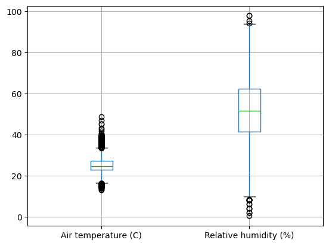

```python
ashrae_data[['Air temperature (C)', 'Relative humidity (%)']].boxplot()
```

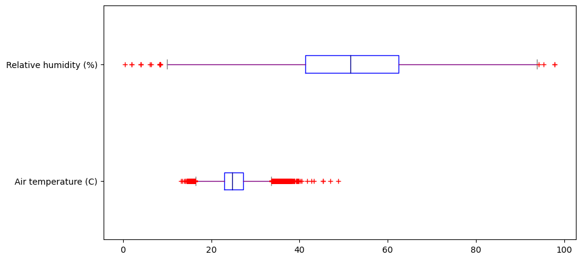

```python
color = {'boxes': 'Blue', 'whiskers': 'purple',  'medians': 'DarkBlue', 'caps': 'Gray'}
ashrae_data[['Air temperature (C)','Relative humidity (%)']].plot.box(color=color, sym='r+', figsize=(10,5), vert=False)
```

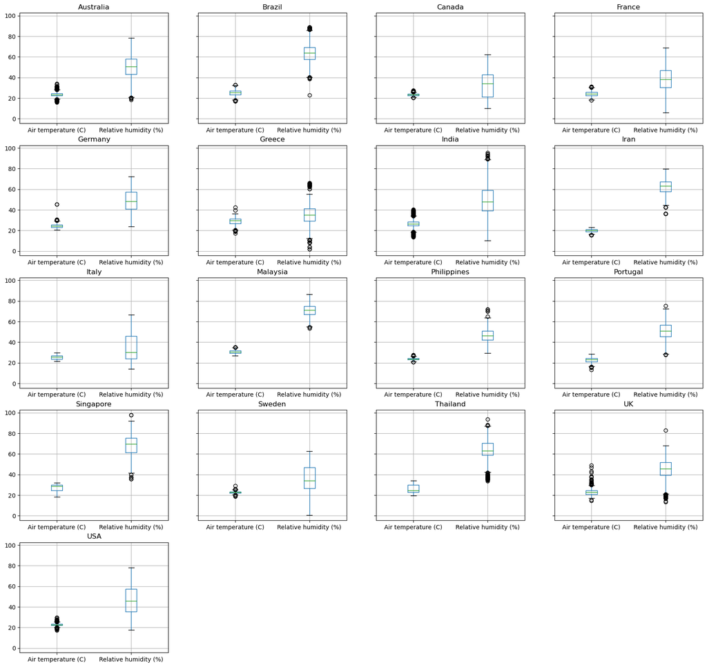

```python
ashrae_data[['Air temperature (C)','Relative humidity (%)','Country']].groupby('Country').boxplot(figsize=(20,20));
```

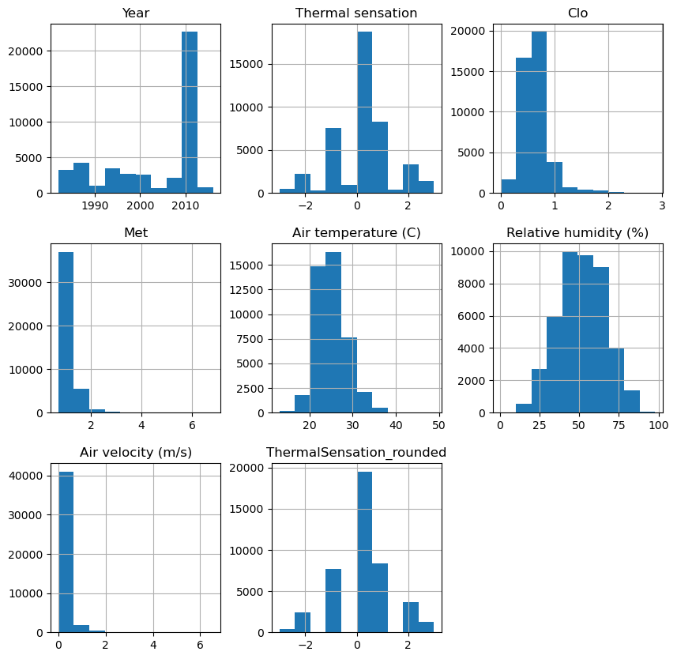

```python
ashrae_data.hist(figsize=(10, 10));
```

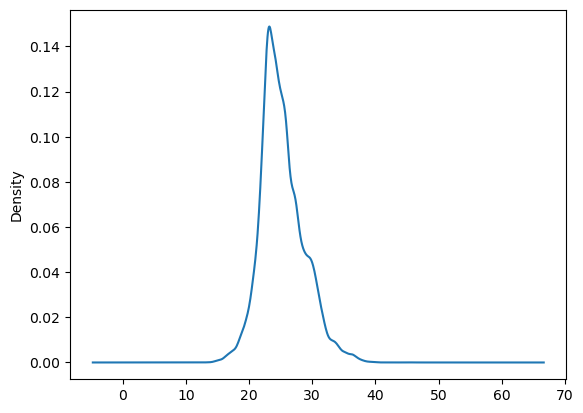

```python
# Density plots
ashrae_data['Air temperature (C)'].plot.kde()
```

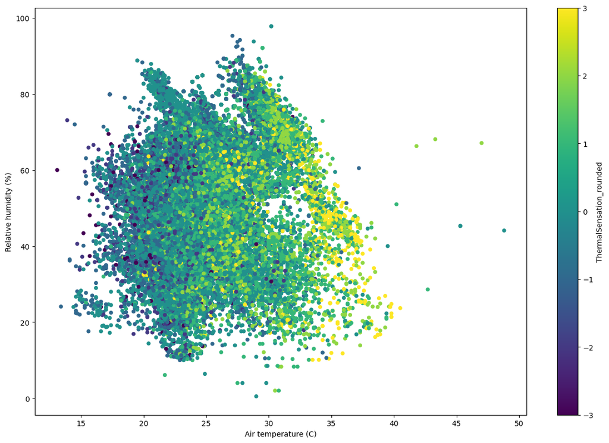

```python
ashrae_data.plot.scatter(x='Air temperature (C)', y='Relative humidity (%)', c='ThermalSensation_rounded', figsize=(15,10));
```

### Parallel Coordinate Plots

Parallel coordinate plots are a multi-variate visualation method to compare several quantitative columns at the same time.

```python
from pandas.plotting import parallel_coordinates
ashrae_data[['Air temperature (C)','Relative humidity (%)','ThermalSensation_rounded','Air velocity (m/s)']].iloc[:500].info()
```

```
<class 'pandas.core.frame.DataFrame'>
Int64Index: 500 entries, 2233 to 2732
Data columns (total 4 columns):
 #   Column                    Non-Null Count  Dtype
---  ------                    --------------  -----
 0   Air temperature (C)       500 non-null    float64
 1   Relative humidity (%)     500 non-null    float64
 2   ThermalSensation_rounded  500 non-null    float64
 3   Air velocity (m/s)        500 non-null    float64
dtypes: float64(4)
memory usage: 19.5 KB
```

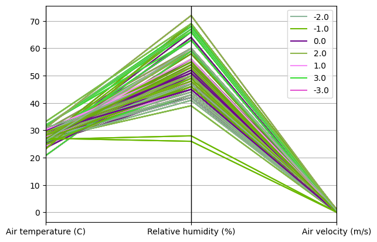

```python
parallel_coordinates(ashrae_data[['Air temperature (C)','Relative humidity (%)','ThermalSensation_rounded','Air velocity (m/s)']].iloc[:500], 'ThermalSensation_rounded');
```

# Conditions comfortable for people ?

practical investigation of the what conditions influence the comfort of occupants in the various contexts that were tested in the ASHRAE Thermal Comfort Database II studies.

We will go through and investigate how temperature, humidity, air movement, and other factors influence comfort.

```python
ashrae_data = pd.read_csv("ashrae_thermal_comfort_database_2.csv", index_col='Unnamed: 0')
```

```python
ashrae_data.head()
```

|  | Publication (Citation) | Year | Season | Climate | City | Country | Building type | Cooling startegy_building level | Sex | Thermal sensation | Clo | Met | Air temperature (C) | Relative humidity (%) | Air velocity (m/s) | ThermalSensation_rounded |
| --- | --- | --- | --- | --- | --- | --- | --- | --- | --- | --- | --- | --- | --- | --- | --- | --- |
| 2233 | Indraganti, Madhavi, et al. "Adaptive model of... | 2012.0 | Winter | Tropical wet savanna | Chennai | India | Office | Mixed Mode | Female | -2.0 | 0.75 | 1.0 | 25.2 | 64.0 | 0.1 | -2.0 |
| 2234 | Indraganti, Madhavi, et al. "Adaptive model of... | 2012.0 | Winter | Tropical wet savanna | Chennai | India | Office | Mixed Mode | Male | -1.0 | 0.64 | 1.0 | 25.2 | 64.0 | 0.1 | -1.0 |
| 2235 | Indraganti, Madhavi, et al. "Adaptive model of... | 2012.0 | Winter | Tropical wet savanna | Chennai | India | Office | Mixed Mode | Male | -2.0 | 0.64 | 1.0 | 25.2 | 64.0 | 0.1 | -2.0 |
| 2236 | Indraganti, Madhavi, et al. "Adaptive model of... | 2012.0 | Winter | Tropical wet savanna | Chennai | India | Office | Mixed Mode | Female | -2.0 | 0.75 | 1.0 | 25.2 | 64.0 | 0.1 | -2.0 |
| 2237 | Indraganti, Madhavi, et al. "Adaptive model of... | 2012.0 | Winter | Tropical wet savanna | Chennai | India | Office | Mixed Mode | Male | 0.0 | 0.72 | 1.0 | 25.2 | 64.0 | 0.1 | 0.0 |